# Tutorial 8: Simple Linear Regression

Jiyeong Pyo

### Variables: GDP and Environmental Performance Index (EPI)

For the tutorial we will explore the relationship between GDP per capita (GDPpc) and the Yale Environmental Performance Index.

The Environmental Performance Index (EPI.new) is an index for each nation on its environmental performance. It is an index combined of numerous weighted measures. Read more about the data on the Yale website and the technical appendix https://epi.yale.edu/downloads/2024epitechnicalappendix20241207.pdf

We will read in the data with read_csv() (a readr function).

### Import GDP per capita data from World Bank (in current USD)

### Renaming the GDP variable

We will now rename “NY.GDP.PCAP.CD” to gdp_pc. The renamed variable will be in the wb_data data frame.

Let’s look at the gdp_pc data to make sure it looks good.

### Selecting variables that we will keep

You should now have three variables in the data frame: iso3c, year, and gdp_pc.

### Joining data Using the full_join() function in dplyr

We should now join wb_data with the epi.df using the three letter country code that is in both data frames epi.df (iso) and wb_data (iso3c). A full join joins all rows that are in either x or y. Call the new joined data frame epi_gdp.df.

Read more about the joining functions in dplyr here: https://dplyr.tidyverse.org/reference/mutate-joins.html https://statisticsglobe.com/r-dplyr-join-inner-left-right-full-semi-anti

We can now make our scatterplot.

### Scatterplots

You will now make a scatter plot of GDP per capita (x) and EPI.new (Y).

You can see in the scatterplot that GDP per capita is positively skewed. We should take the log of GDP per capita and then make the scatterplot with the logged gdp_pc data. Use the mutate() function to add in log_gdp_pc to the epi_gdp.df data frame. Do so in the chunk below.

Develop a scatter plot of EPI.new ~ log_gdp_pc. Notice the units on the Y-axis. You can set the limits of the y axis by adding the code: ylim(0,100). Use geom_point to add text labels to the plot and set label=iso in the aesthetic. Please add appropriate labels for the x- and y-axes.

We could also visualize the original data on a log scale of the x-axis by adding scale_x_log10(). This adjusts the scale to log10.

**Q1: What is the advantage of using this approach to visualizing the data vs logging the data and plotting the logged data? Any disadvantages?** The logged data helps to eliminating the skewness so it becomes more linear than the original data.

## Calculating correlations

The correlation coefficient (r) is a measure of linear relationship and can range between -1 and 1.

Please calculate the correlation coefficients on both the original data (EPI.new and gdp_pc) and the (natural) logged data of GDPpc.

The function for correlation coefficient is cor(). For correlations, it does not matter which variable you place first. if there are missing data, you should use the argument use=“pairwise.complete.obs”. Please type ?cor in the console so you can see the arguments before running the chunk below.

## Simple linear model

The function to run a linear model in R is lm()

To see the arguments of lm() please type ?lm in the console.

The model is written Y~X.

```r
model.1 <- lm(EPI.new ~ gdp_pc , data = epi_gdp.df)
model.1
```

```
##
## Call:
## lm(formula = EPI.new ~ gdp_pc, data = epi_gdp.df)
##
## Coefficients:
## (Intercept)       gdp_pc
##  41.0009644    0.0003437
```

The output of R gives us the equation for the simple linear model. The equation can be written as **Predicted EPI.new = 41.00 + 0.0003437 * GDPpc**

**Question 3: Why do you think the slope is such a small number?**

We can interpret this equation as, a one dollar increase in per capita GDP is associated with a 0.0003437 increase in predicted Environmental Performance Index. A dollar is such a small amount, so it is probably better to interpret in terms of $1000 increase in GDPpc is associated with a 0.3437 increase in predicted Environmental Performance Index. I calculated this number by multiplying 1000 * 0.0003437.

We can also summarize the model to see the estimates, SE, t, and p-values as well as the R-squared value and F-statistic.

```r
summary(model.1)
```

```
##
## Call:
## lm(formula = EPI.new ~ gdp_pc, data = epi_gdp.df)
##
## Residuals:
##      Min       1Q   Median       3Q      Max
## -20.4143  -5.1217   0.4864   5.1906  23.9870
##
## Coefficients:
##                Estimate  Std. Error t value            Pr(>|t|)
## (Intercept) 41.00096437  0.77192464   53.12 <0.0000000000000002 ***
## gdp_pc       0.00034366  0.00002564   13.40 <0.0000000000000002 ***
## ---
## Signif. codes:  0 '***' 0.001 '**' 0.01 '*' 0.05 '.' 0.1 ' ' 1
##
## Residual standard error: 8.059 on 168 degrees of freedom
##   (46 observations deleted due to missingness)
## Multiple R-squared:  0.5167, Adjusted R-squared:  0.5139
## F-statistic: 179.6 on 1 and 168 DF,  p-value: < 0.00000000000000022
```

We can now add a linear regression line to the plot. This is the line that is drawn by ordinary least squares (OLS). We can use the function geom_smooth and the argument method=lm to tell it to draw the line that we calculated from a linear model.

This will draw the confidence interval around the line based on the linear model.

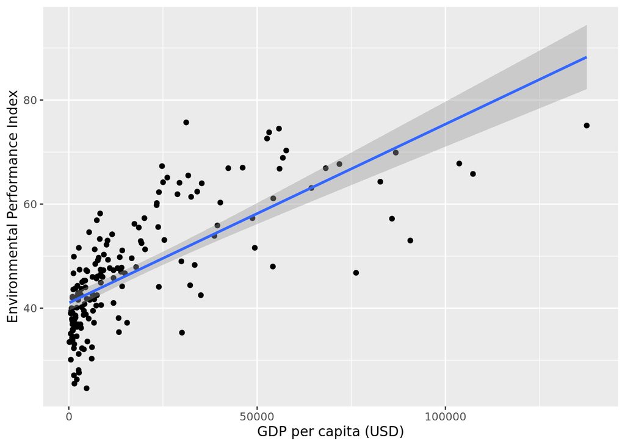

```r
p3<-ggplot(data=epi_gdp.df, aes(x = gdp_pc, y = EPI.new)) +
  geom_point() +
  geom_smooth(method=lm)+
  labs(x="GDP per capita (USD)", y="Environmental Performance Index")

p3
```

We should run the simple linear model using the log_gdp_pc data.

```r
model.2 <- lm(EPI.new ~ log_gdp_pc , data = epi_gdp.df)
model.2
```

```
##
## Call:
## lm(formula = EPI.new ~ log_gdp_pc, data = epi_gdp.df)
##
## Coefficients:
## (Intercept)   log_gdp_pc
##      -9.152        6.306
```

```r
summary(model.2)
```

```
##
## Call:
## lm(formula = EPI.new ~ log_gdp_pc, data = epi_gdp.df)
##
## Residuals:
##      Min       1Q   Median       3Q      Max
## -20.5674  -4.1551   0.4234   5.0214  19.6015
##
## Coefficients:
##             Estimate Std. Error t value            Pr(>|t|)
## (Intercept)   -9.152      3.601  -2.541              0.0119 *
## log_gdp_pc     6.306      0.398  15.843 <0.0000000000000002 ***
## ---
## Signif. codes:  0 '***' 0.001 '**' 0.01 '*' 0.05 '.' 0.1 ' ' 1
##
## Residual standard error: 7.341 on 168 degrees of freedom
##   (46 observations deleted due to missingness)
## Multiple R-squared:  0.599,  Adjusted R-squared:  0.5967
## F-statistic:   251 on 1 and 168 DF,  p-value: < 0.00000000000000022
```

As you might have guessed, we now have a new equation when we use logGDPpc. We no longer have a linear model, but rather what we call a linear-log model. To interpret a linear-log model, an increase in x (GDPpc) by one percent is associated with an increase in predicted y by ($\beta$/100) units (EPI).

So, a 1% increase in per capita GDP is associated with a 0.0631 increase in predicted EPI. The R-squared is now 0.60.

Let’s use the package broom to make a nice tidy tibble of the regression results. First I’ll turn scientific notation back on.

```r
options(scipen=0) #turn scientific notation back on. I'm turning it back on to get reasonable looking p-values
tidy(summary(model.2))
```

```
## # A tibble: 2 × 5
##   term        estimate std.error statistic  p.value
##   <chr>          <dbl>     <dbl>     <dbl>    <dbl>
## 1 (Intercept)    -9.15     3.60      -2.54 1.19e- 2
## 2 log_gdp_pc      6.31     0.398     15.8  3.62e-35
```

Let’s make a new scatterplot with the loggedGDPpc data that includes the regression line. Please run the chunk below.

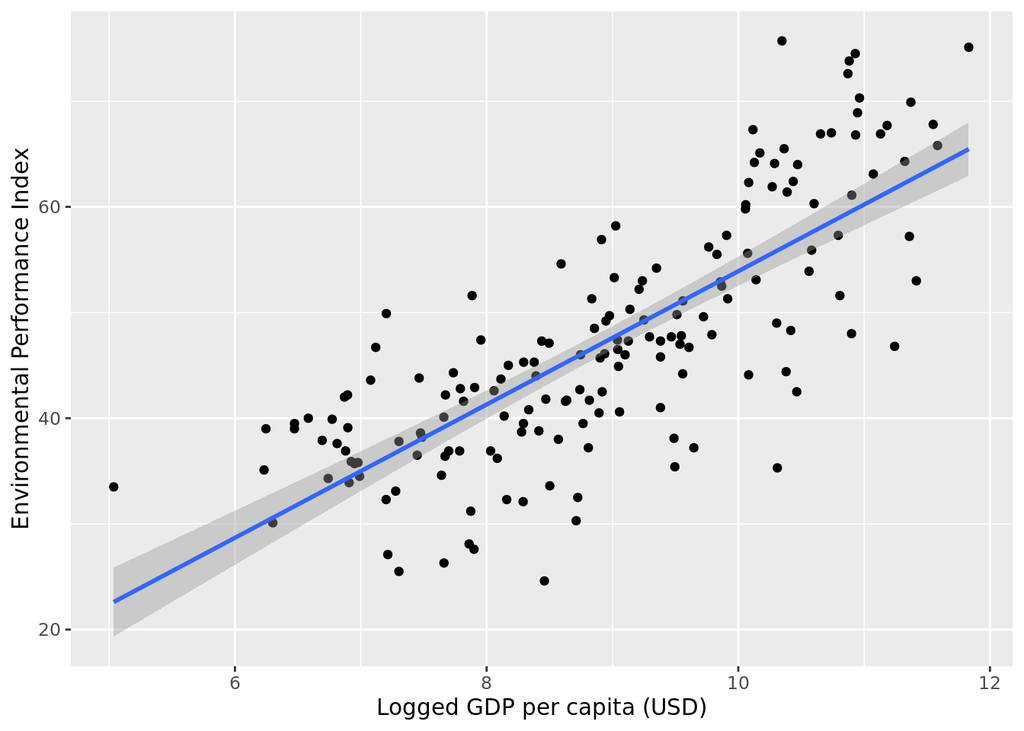

```r
p4<-ggplot(data=epi_gdp.df, aes(x = log_gdp_pc, y = EPI.new)) +
  geom_point() +
  geom_smooth(method=lm)+
  labs(x="Logged GDP per capita (USD)", y="Environmental Performance Index")
p4
```

Awesome! That scatter plot looks pretty darn good. If we are meeting the assumptions of ordinary least squares, we want equal spread of the observations above and below the regression line across all values of our explanatory variable (log gdp per capita).

**Question 5 (a, b, and c)**

**Now it is your turn to play around with one of the other variables in the Yale EPI dataset. Please look at its relationship with log GDP per capita (x).

Please develop:

1. a scatterplot,

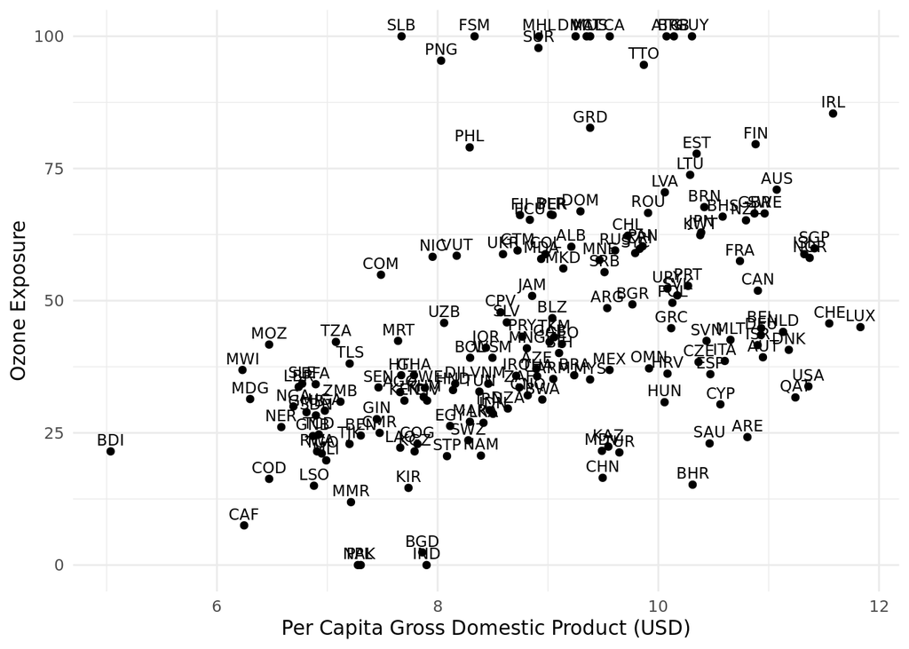

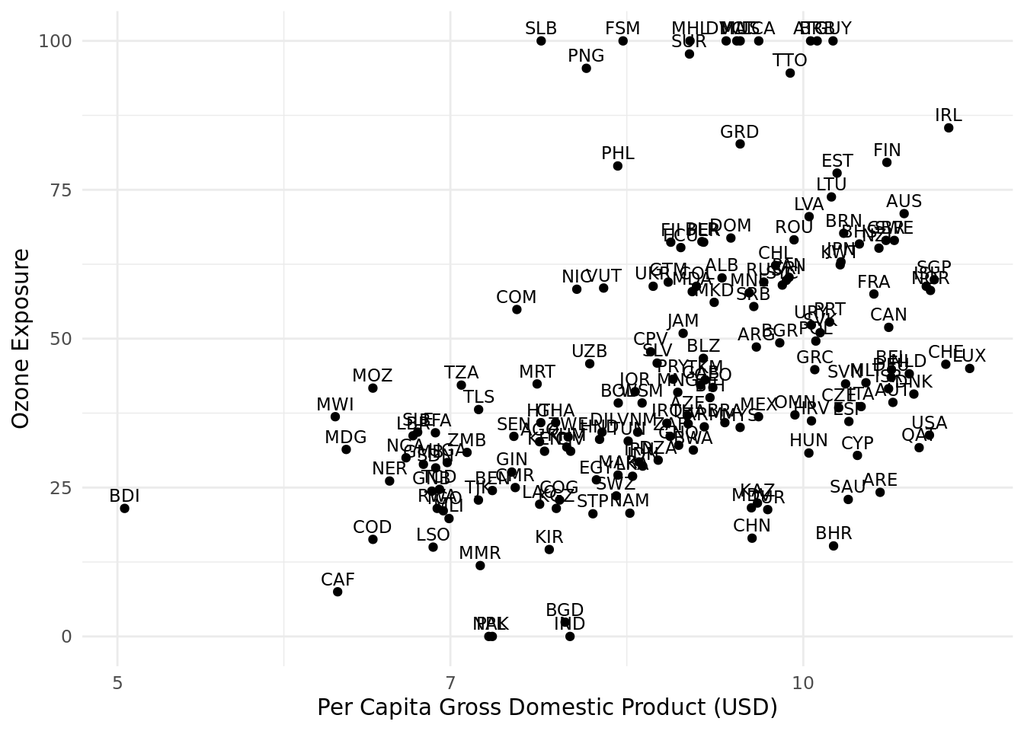

2. calculate a correlation coefficient, and

```
## [1] 0.4265249
```

3. Develop and interpret an appropriate simple linear regression model.** The logged GDP and the Ozone Exposure level has significant correlation (The Pr(>|t|)is 6.65e-09 *** so we can reject the null hypothesis.)

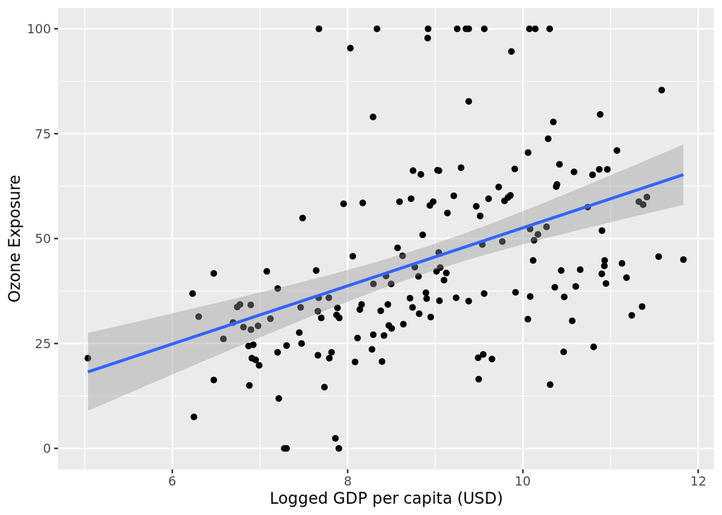

```
##
## Call:
## lm(formula = OZD.new ~ log_gdp_pc, data = epi_gdp.df)
##
## Coefficients:
## (Intercept)   log_gdp_pc
##      -16.63         6.92
```

```
##
## Call:
## lm(formula = OZD.new ~ log_gdp_pc, data = epi_gdp.df)
##
## Residuals:
##     Min      1Q  Median      3Q     Max
## -39.525 -13.592  -2.938   9.170  63.529
##
## Coefficients:
##             Estimate Std. Error t value Pr(>|t|)
## (Intercept)  -16.627     10.243  -1.623    0.106
## log_gdp_pc     6.920      1.132   6.112 6.65e-09 ***
## ---
## Signif. codes:  0 '***' 0.001 '**' 0.01 '*' 0.05 '.' 0.1 ' ' 1
##
## Residual standard error: 20.88 on 168 degrees of freedom
##   (46 observations deleted due to missingness)
## Multiple R-squared:  0.1819, Adjusted R-squared:  0.1771
## F-statistic: 37.36 on 1 and 168 DF,  p-value: 6.646e-09
```

```r
options(scipen=0)
tidy(summary(model.2))
```

```
## # A tibble: 2 × 5
##   term        estimate std.error statistic       p.value
##   <chr>          <dbl>     <dbl>     <dbl>         <dbl>
## 1 (Intercept)   -16.6      10.2      -1.62 0.106
## 2 log_gdp_pc      6.92      1.13      6.11 0.00000000665
```

Prior to selecting your variable, please skim the Policymaker’s Summary, the EPI Report, and the Technical Appendix which can be found here: https://epi.yale.edu/downloads

**Please knit to html and upload to Assignments before lecture on Wednesday.**

### Congratulations on finishing Tutorial 8!